# Metabolic Syndrome

Nikola Lalić, Luka Ivanović

## Uvod

Metabolic Syndrome predstavlja set podataka koji sadrži informacije o pojedincima sa metaboličkim sindromom, složenim medicinskim stanjem povezanim sa skupom faktora rizika za kardiovaskularne bolesti i dijabetes tip 2. Podaci uključuju demografska, klinička i laboratorijska merenja, kao i prisustvo ili odsustvo metaboličkog sindroma.

**Link za korišćeni dataset:** https://www.kaggle.com/datasets/antimoni/metabolic-syndrome

## Opis podataka

Dimenzije seta podataka su 2401 15. Kolone Marital, Income, WaistCirc i BMI sadrže nedostajuće vrednosti. Atributi su sledeći:

- **Seqn** - Identifikacioni broj
- **Age** - Godine
- **Sex** - Pol
- **Marital** - Bračni status
- **Income** - Mesečni prihod
- **Race** - Rasa
- **WaistCirc** - Obim struka
- **BMI** - Body mass index
- **Albuminuria** - Albumin u urinu
- **UrAlbCr** - Odnos albumina i kreatinina u urinu
- **UricAcid** - Nivo mokraćne kiseline u krvi
- **BloodGlucose** - Nivo glukoze u krvi
- **HDL** - Nivo dobrog holesterola
- **Triglycerides** - Nivo triglicerida u krvi
- **MetabolicSyndrome** - 1 za prisustvo, 0 za odsustvo

## Učitavanje biblioteka i skupa podataka

```r
library(tidyverse)
library(caret)
library(rpart)
library(rpart.plot)
library(corrplot)
library(VIM)
library(rsample)
library(dplyr)
library(nnet)
```

Prvo učitavamo set podataka u promenjivu **data** i **dataPom**

```r
data = read.csv("Metabolic Syndrome.csv", stringsAsFactors = F)
dataPom <- read.csv("Metabolic Syndrome.csv")
```

Pre daljeg ispitivanja proverićemo ditribuciju naše target promenjive. Pre toga ćemo je faktorisati.

```r
data$MetabolicSyndrome <- ifelse(data$MetabolicSyndrome == 1, "Yes", "No")
data$MetabolicSyndrome <- factor(data$MetabolicSynd)
summary(data)
```

```
      seqn            Age            Sex              Marital              Income
 Min.   :62161   Min.   :20.00   Length:2401        Length:2401        Min.   : 300
 1st Qu.:64591   1st Qu.:34.00   Class :character   Class :character   1st Qu.:1600
 Median :67059   Median :48.00   Mode  :character   Mode  :character   Median :2500
 Mean   :67031   Mean   :48.69                                         Mean   :4005
 3rd Qu.:69495   3rd Qu.:63.00                                         3rd Qu.:6200
 Max.   :71915   Max.   :80.00                                         Max.   :9000
                                                                       NA's   :117
     Race             WaistCirc           BMI        Albuminuria        UrAlbCr           UricAcid
 Length:2401        Min.   : 56.20   Min.   :13.4   Min.   :0.0000   Min.   :   1.40   Min.   : 1.800
 Class :character   1st Qu.: 86.67   1st Qu.:24.0   1st Qu.:0.0000   1st Qu.:   4.45   1st Qu.: 4.500
 Mode  :character   Median : 97.00   Median :27.7   Median :0.0000   Median :   7.07   Median : 5.400
                    Mean   : 98.31   Mean   :28.7   Mean   :0.1541   Mean   :  43.63   Mean   : 5.489
                    3rd Qu.:107.62   3rd Qu.:32.1   3rd Qu.:0.0000   3rd Qu.:  13.69   3rd Qu.: 6.400
                    Max.   :176.00   Max.   :68.7   Max.   :2.0000   Max.   :5928.00   Max.   :11.300
                    NA's   :85       NA's   :26
  BloodGlucose        HDL         Triglycerides    MetabolicSyndrome
 Min.   : 39.0   Min.   : 14.00   Min.   :  26.0   No :1579
 1st Qu.: 92.0   1st Qu.: 43.00   1st Qu.:  75.0   Yes: 822
 Median : 99.0   Median : 51.00   Median : 103.0
 Mean   :108.2   Mean   : 53.37   Mean   : 128.1
 3rd Qu.:110.0   3rd Qu.: 62.00   3rd Qu.: 150.0
 Max.   :382.0   Max.   :156.00   Max.   :1562.0
```

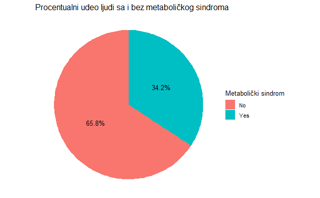

```r
data_summary <- data %>%
  group_by(MetabolicSyndrome) %>%
  summarise(Count = n()) %>%
  mutate(Percentage = Count / sum(Count) * 100)

ggplot(data_summary, aes(x = "", y = Percentage, fill = MetabolicSyndrome)) +
  geom_bar(stat = "identity", width = 1) +
  coord_polar("y", start = 0) +
  labs(
    title = "Procentualni udeo ljudi sa i bez metaboličkog sindroma",
    fill = "Metabolički sindrom"
  ) +
  theme_void() +  # Uklanja osi i pozadinu za lepši izgled
  geom_text(aes(label = paste0(round(Percentage, 1), "%")),
            position = position_stack(vjust = 0.5))
```

Možemo primetiti da u našem setu podataka imamo više ljudi koji nema sindrom nego onih koji imaju.

## Ispitivanje i vizualizacija podataka

U ovom odeljku ćemo proveriti da li postoje NULL vrednosti i proverićemo da li postoji neke irelevantne vrednosti (duplikati, greške u pisanju, prazni stringovi). Ovo nam je izuzetno važan korak jer nam od njega zavisi rad samog modela.

#### NULL i irelevantne vrednosti

```r
length(which(data$Sex == ""))
```

```
[1] 0
```

```r
length(which(data$Marital == ""))
```

```
[1] 208
```

```r
length(which(data$Race == ""))
```

```
[1] 0
```

Vidimo da Marital ima nedostajuće vrednosti. Ima ih 208 od ukupno 2401 sto je otprilike 8.67%, hajde da vidimo kako možemo da ih popunimo.

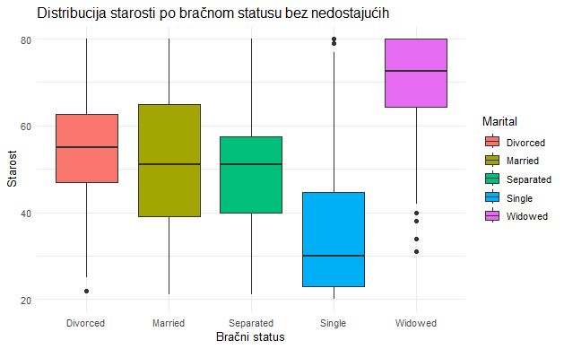

```r
ggplot(filter(data, data$Marital != ""), aes(x = Marital, y = Age)) +
  geom_boxplot(aes(fill = Marital)) +
  labs(
    title = "Distribucija starosti po bračnom statusu bez nedostajućih",
    x = "Bračni status",
    y = "Starost"
  ) +
  theme_minimal()
```

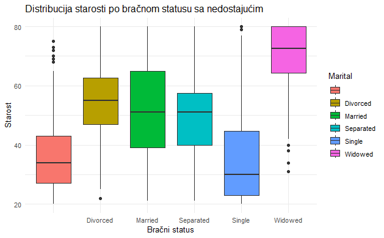

```r
ggplot(data, aes(x = Marital, y = Age)) +
  geom_boxplot(aes(fill = Marital)) +
  labs(
    title = "Distribucija starosti po bračnom statusu sa nedostajućim",
    x = "Bračni status",
    y = "Starost"
  ) +
  theme_minimal()
```

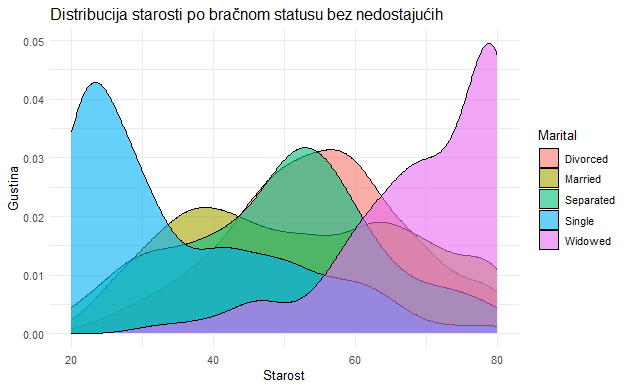

```r
ggplot(filter(data, data$Marital != ""), aes(x = Age, fill = Marital)) +
  geom_density(alpha = 0.6) +
  labs(
    title = "Distribucija starosti po bračnom statusu bez nedostajućih",
    x = "Starost",
    y = "Gustina"
  ) +
  theme_minimal()
```

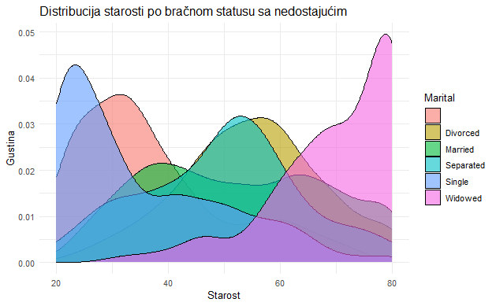

```r
ggplot(data, aes(x = Age, fill = Marital)) +
  geom_density(alpha = 0.6) +
  labs(
    title = "Distribucija starosti po bračnom statusu sa nedostajućim",
    x = "Starost",
    y = "Gustina"
  ) +
  theme_minimal()
```

Na osnovu ove raspodele možemo utvrditi da godine utiču na bračni status i da raspodela naših nedostajućih vrednosti najviše podseća na raspodelu single ljudi.

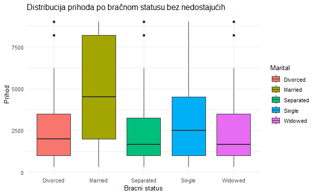

```r
ggplot(filter(data, data$Marital != ""), aes(x = Marital, y = Income)) +
  geom_boxplot(aes(fill = Marital)) +
  labs(
    title = "Distribucija prihoda po bračnom statusu bez nedostajućih",
    x = "Bracni status",
    y = "Prihod"
  ) +
  theme_minimal()
```

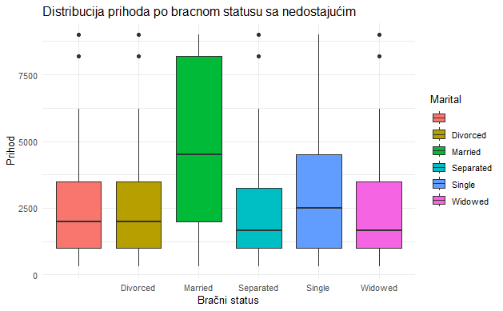

```r
ggplot(data, aes(x = Marital, y = Income)) +
  geom_boxplot(aes(fill = Marital)) +
  labs(
    title = "Distribucija prihoda po bracnom statusu sa nedostajućim",
    x = "Bračni status",
    y = "Prihod"
  ) +
  theme_minimal()
```

Ovde možemo zaključiti, kao što je i logično da ljudi u braku najviše zaradjuju, ali je zanimljivo i to da su sledeći single ljudi.

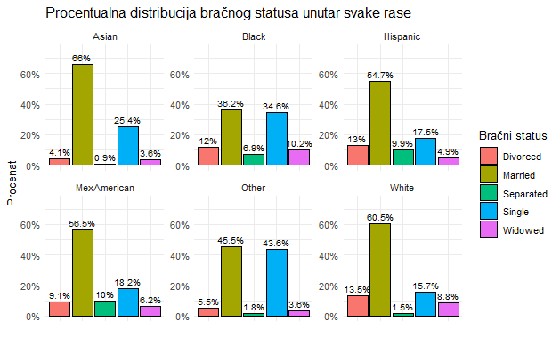

```r
data_summary_race_marital <- filter(data, data$Marital != "") %>%
  group_by(Race, Marital) %>%
  summarise(count = n(), .groups = 'drop') %>%
  group_by(Race) %>%
  mutate(percentage = count / sum(count) * 100)
ggplot(data_summary_race_marital, aes(x = Marital, y = percentage, fill = Marital)) +
  geom_bar(stat = "identity", position = position_dodge(width = 0.9), color = "black") +
  geom_text(aes(label = paste0(round(percentage, 1), "%")),
            position = position_dodge(width = 0.9), vjust = -0.5, size = 3) +
  labs(
    title = "Procentualna distribucija bračnog statusa unutar svake rase",
    x = "",
    y = "Procenat",
    fill = "Bračni status"
  ) +
  theme_minimal() +
  theme(axis.text.x = element_blank(), axis.ticks.x = element_blank()) +
  facet_wrap(~ Race, scales = "free_y") +
  scale_y_continuous(labels = scales::percent_format(scale = 1), limits = c(0, 75))
```

Ono što možemo da primetimo jeste da kod svih rasa, sem Black i Other, dominira Married bračni status. Kod Black i Other vidimo da je procentualno Married i Single otprilike na istoj lestivici. Da vidimo sada da li kategorijske promenjive imaju vrednosti koje se ponavljaju.

```r
unique(data$Marital)
```

```
[1] "Single"    "Married"   "Widowed"   "Divorced"  ""          "Separated"
```

```r
unique(data$Race)
```

```
[1] "White"       "Asian"       "Black"       "MexAmerican" "Hispanic"    "Other"
```

```r
unique(data$Sex)
```

```
[1] "Male"   "Female"
```

Sada kada smo ustanovili da ove kategorijske promenjive imaju sve nekoliko vrednosti, njih ćemo da faktorišemo.

```r
data$Marital = factor(data$Marital)
data$Sex = factor(data$Sex)
data$Race = factor(data$Race)
summary(data)
```

```
      seqn            Age            Sex            Marital         Income              Race
 Min.   :62161   Min.   :20.00   Female:1211            : 208   Min.   : 300   Asian      :349
 1st Qu.:64591   1st Qu.:34.00   Male  :1190   Divorced : 242   1st Qu.:1600   Black      :548
 Median :67059   Median :48.00                 Married  :1192   Median :2500   Hispanic   :257
 Mean   :67031   Mean   :48.69                 Separated:  95   Mean   :4005   MexAmerican:253
 3rd Qu.:69495   3rd Qu.:63.00                 Single   : 498   3rd Qu.:6200   Other      : 61
 Max.   :71915   Max.   :80.00                 Widowed  : 166   Max.   :9000   White      :933
                                                                NA's   :117
   WaistCirc           BMI        Albuminuria        UrAlbCr           UricAcid       BloodGlucose
 Min.   : 56.20   Min.   :13.4   Min.   :0.0000   Min.   :   1.40   Min.   : 1.800   Min.   : 39.0
 1st Qu.: 86.67   1st Qu.:24.0   1st Qu.:0.0000   1st Qu.:   4.45   1st Qu.: 4.500   1st Qu.: 92.0
 Median : 97.00   Median :27.7   Median :0.0000   Median :   7.07   Median : 5.400   Median : 99.0
 Mean   : 98.31   Mean   :28.7   Mean   :0.1541   Mean   :  43.63   Mean   : 5.489   Mean   :108.2
 3rd Qu.:107.62   3rd Qu.:32.1   3rd Qu.:0.0000   3rd Qu.:  13.69   3rd Qu.: 6.400   3rd Qu.:110.0
 Max.   :176.00   Max.   :68.7   Max.   :2.0000   Max.   :5928.00   Max.   :11.300   Max.   :382.0
 NA's   :85       NA's   :26
      HDL         Triglycerides    MetabolicSyndrome
 Min.   : 14.00   Min.   :  26.0   No :1579
 1st Qu.: 43.00   1st Qu.:  75.0   Yes: 822
 Median : 51.00   Median : 103.0
 Mean   : 53.37   Mean   : 128.1
 3rd Qu.: 62.00   3rd Qu.: 150.0
 Max.   :156.00   Max.   :1562.0
```

S obzirom da Income ima najvise null vrednosti 117, to je 4.87% broja redova, featuri koji su numerički popunićemo sa mean ili median u zavisnosti od raspodele

```r
shapiro.test(data$Income)
```

```
    Shapiro-Wilk normality test

data:  data$Income
W = 0.85909, p-value < 2.2e-16
```

p-value je manja od 0.05, što znači da podaci nisu normalno distribuirani tako da ćemo ovu kolonu popuniti medijanom

```r
medIncome <- median(data$Income, na.rm = TRUE)
medIncome
```

```
[1] 2500
```

```r
data$Income[is.na(data$Income)] <- medIncome
```

```r
shapiro.test(data$WaistCirc)
```

```
    Shapiro-Wilk normality test

data:  data$WaistCirc
W = 0.97732, p-value < 2.2e-16
```

```r
medWaistCirc <- median(data$WaistCirc, na.rm = TRUE)
medWaistCirc
```

```
[1] 97
```

```r
data$WaistCirc[is.na(data$WaistCirc)] <- medWaistCirc
```

```r
shapiro.test(data$BMI)
```

```
    Shapiro-Wilk normality test

data:  data$BMI
W = 0.94161, p-value < 2.2e-16
```

```r
medBMI <- median(data$BMI, na.rm = TRUE)
medBMI
```

```
[1] 27.7
```

```r
data$BMI[is.na(data$BMI)] <- medBMI
```

```r
summary(data)
```

```
      seqn            Age            Sex            Marital         Income              Race
 Min.   :62161   Min.   :20.00   Female:1211            : 208   Min.   : 300   Asian      :349
 1st Qu.:64591   1st Qu.:34.00   Male  :1190   Divorced : 242   1st Qu.:1600   Black      :548
 Median :67059   Median :48.00                 Married  :1192   Median :2500   Hispanic   :257
 Mean   :67031   Mean   :48.69                 Separated:  95   Mean   :3932   MexAmerican:253
 3rd Qu.:69495   3rd Qu.:63.00                 Single   : 498   3rd Qu.:6200   Other      : 61
 Max.   :71915   Max.   :80.00                 Widowed  : 166   Max.   :9000   White      :933
   WaistCirc           BMI         Albuminuria        UrAlbCr           UricAcid       BloodGlucose
 Min.   : 56.20   Min.   :13.40   Min.   :0.0000   Min.   :   1.40   Min.   : 1.800   Min.   : 39.0
 1st Qu.: 87.00   1st Qu.:24.00   1st Qu.:0.0000   1st Qu.:   4.45   1st Qu.: 4.500   1st Qu.: 92.0
 Median : 97.00   Median :27.70   Median :0.0000   Median :   7.07   Median : 5.400   Median : 99.0
 Mean   : 98.26   Mean   :28.69   Mean   :0.1541   Mean   :  43.63   Mean   : 5.489   Mean   :108.2
 3rd Qu.:107.20   3rd Qu.:32.00   3rd Qu.:0.0000   3rd Qu.:  13.69   3rd Qu.: 6.400   3rd Qu.:110.0
 Max.   :176.00   Max.   :68.70   Max.   :2.0000   Max.   :5928.00   Max.   :11.300   Max.   :382.0
      HDL         Triglycerides    MetabolicSyndrome
 Min.   : 14.00   Min.   :  26.0   No :1579
 1st Qu.: 43.00   1st Qu.:  75.0   Yes: 822
 Median : 51.00   Median : 103.0
 Mean   : 53.37   Mean   : 128.1
 3rd Qu.: 62.00   3rd Qu.: 150.0
 Max.   :156.00   Max.   :1562.0
```

Za nedostajuće vrednosti Marital, napravićemo model multinominalne logističke regresije koji će da predvidja bračni status.

```r
data$Marital[data$Marital == ""] <- NA
data$Marital <- factor(data$Marital)
df_known <- na.omit(data)
model <- multinom(Marital ~ Age + Income + Race, data = df_known, maxit = 1000)
df_missing <- data %>% filter(is.na(Marital))
predicted_marital <- predict(model, newdata = df_missing)
data$Marital[is.na(data$Marital)] <- predicted_marital
summary(data)
```

```
      seqn            Age            Sex            Marital         Income              Race
 Min.   :62161   Min.   :20.00   Female:1211   Divorced : 242   Min.   : 300   Asian      :349
 1st Qu.:64591   1st Qu.:34.00   Male  :1190   Married  :1303   1st Qu.:1600   Black      :548
 Median :67059   Median :48.00                 Separated:  95   Median :2500   Hispanic   :257
 Mean   :67031   Mean   :48.69                 Single   : 595   Mean   :3932   MexAmerican:253
 3rd Qu.:69495   3rd Qu.:63.00                 Widowed  : 166   3rd Qu.:6200   Other      : 61
 Max.   :71915   Max.   :80.00                                  Max.   :9000   White      :933
   WaistCirc           BMI         Albuminuria        UrAlbCr           UricAcid       BloodGlucose
 Min.   : 56.20   Min.   :13.40   Min.   :0.0000   Min.   :   1.40   Min.   : 1.800   Min.   : 39.0
 1st Qu.: 87.00   1st Qu.:24.00   1st Qu.:0.0000   1st Qu.:   4.45   1st Qu.: 4.500   1st Qu.: 92.0
 Median : 97.00   Median :27.70   Median :0.0000   Median :   7.07   Median : 5.400   Median : 99.0
 Mean   : 98.26   Mean   :28.69   Mean   :0.1541   Mean   :  43.63   Mean   : 5.489   Mean   :108.2
 3rd Qu.:107.20   3rd Qu.:32.00   3rd Qu.:0.0000   3rd Qu.:  13.69   3rd Qu.: 6.400   3rd Qu.:110.0
 Max.   :176.00   Max.   :68.70   Max.   :2.0000   Max.   :5928.00   Max.   :11.300   Max.   :382.0
      HDL         Triglycerides    MetabolicSyndrome
 Min.   : 14.00   Min.   :  26.0   No :1579
 1st Qu.: 43.00   1st Qu.:  75.0   Yes: 822
 Median : 51.00   Median : 103.0
 Mean   : 53.37   Mean   : 128.1
 3rd Qu.: 62.00   3rd Qu.: 150.0
 Max.   :156.00   Max.   :1562.0
```

## Matrica korelacije

Hajde pre svega da pogledamo matricu korelacije izmedju naših promenjivih.

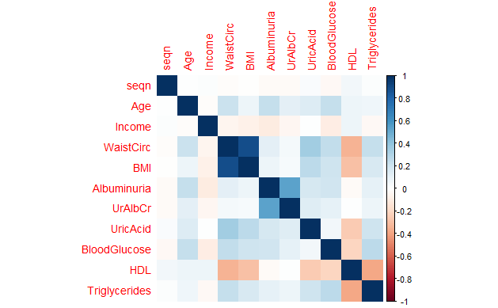

```r
numeric_data <- data[, sapply(data, is.numeric)]
library(corrplot)
matrix = cor(numeric_data)
corrplot(matrix, method="color")
```

## Zavisnost promenjivih sa targetom

Ovaj odeljak je posvećen proučavanju zavisnosti svih naših promenjivih sa targetom. Cilj nam je ustanoviti da li postoje neke relacije izmedju pojedinačnih promenjivih i našeg targeta. U zavisnosti od toga, videćemo koje ćemo promenjive uključiti u naš model i kako.

#### Zavisnost promenjive Sex i MetaboliSyndrome

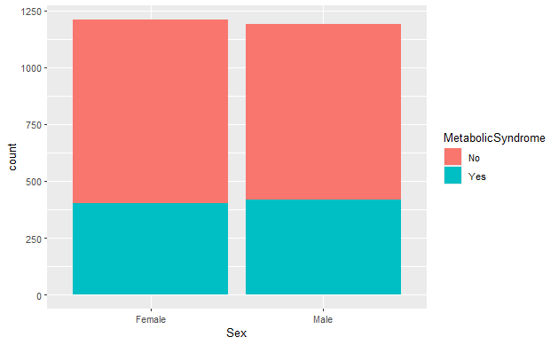

```r
ggplot(data = data, aes(x = Sex, fill = MetabolicSyndrome)) + geom_bar()
```

```r
contingency_table <- table(data$Sex, data$MetabolicSyndrome)
chi_square_result <- chisq.test(contingency_table)
print(chi_square_result)
```

```
    Pearson's Chi-squared test with Yates' continuity correction

data:  contingency_table
X-squared = 0.91089, df = 1, p-value = 0.3399
```

Kao što možemo da vidimo sa grafika, od metaboličkog sindrom oboljevaju i osobe muškog pola i osobe ženskog pola. Pol nam ne pravi razliku pa ćemo njega za sada smatrati nebitnim featurom. I ChiSquare test nam je pokazao da nam je pol neuticajna promenjiva.

#### Zavisnost promenjive Marital i MetabolicSyndrome

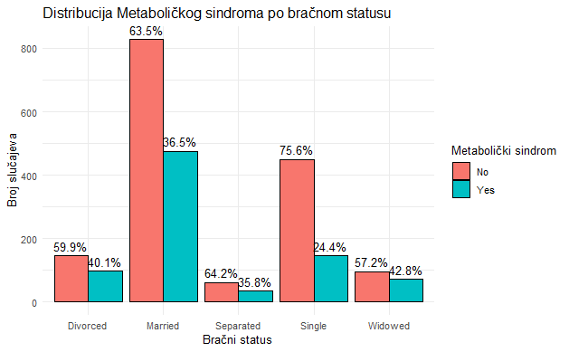

```r
data_summary_marital <- data %>%
  group_by(Marital, MetabolicSyndrome) %>%
  summarise(count = n(), .groups = 'drop') %>%
  group_by(Marital) %>%
  mutate(percentage = count / sum(count) * 100)

ggplot(data_summary_marital, aes(x = Marital, y = count, fill = MetabolicSyndrome)) +
  geom_bar(stat = "identity", position = position_dodge(width = 0.9), color = "black") +
  geom_text(aes(label = paste0(round(percentage, 1), "%")),
            position = position_dodge(width = 0.9), vjust = -0.5) +
  labs(
    title = "Distribucija Metaboličkog sindroma po bračnom statusu",
    x = "Bračni status",
    y = "Broj slučajeva",
    fill = "Metabolički sindrom"
  ) +
  theme_minimal()
```

```r
contingency_table <- table(data$Marital, data$MetabolicSyndrome)
chi_square_result <- chisq.test(contingency_table)
print(chi_square_result)
```

```
    Pearson's Chi-squared test

data:  contingency_table
X-squared = 37.72, df = 4, p-value = 1.28e-07
```

Sa grafika vidimo da Divorced i Widowed ljudi imaju veće tendencije da obole od metaboličkog sindroma, skoro polovina. Separated i Married ljudi oboljevaju malo manje, otprilike jedna trećina, dok Single ljudi oboljevaju najmanje, otprilike jedna četvrtina. Pretpostavljamo da Marital utiče na sindrom tako da ćemo ovu promenjivu imati u obzir prilikom pravljenja modela. ChiSquare test je potvrdio našu pretpostavku i ova promenjiva je važna za naš model.

#### Zavisnost promenjive Race i MetabolicSyndrome

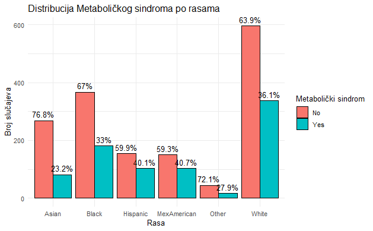

```r
data_summary_race <- data %>%
  group_by(Race, MetabolicSyndrome) %>%
  summarise(count = n(), .groups = 'drop') %>%
  group_by(Race) %>%
  mutate(percentage = count / sum(count) * 100)
ggplot(data_summary_race, aes(x = Race, y = count, fill = MetabolicSyndrome)) +
  geom_bar(stat = "identity", position = position_dodge(width = 0.9), color = "black") +
  geom_text(aes(label = paste0(round(percentage, 1), "%")),
            position = position_dodge(width = 0.9), vjust = -0.5) +
  labs(
    title = "Distribucija Metaboličkog sindroma po rasama",
    x = "Rasa",
    y = "Broj slučajeva",
    fill = "Metabolički sindrom"
  ) +
  theme_minimal()
```

```r
contingency_table <- table(data$Race, data$MetabolicSyndrome)
chi_square_result <- chisq.test(contingency_table)
print(chi_square_result)
```

```
    Pearson's Chi-squared test

data:  contingency_table
X-squared = 30.379, df = 5, p-value = 1.242e-05
```

Sa ovog grafika vidimo da Hispanic i MexAmerican najviše oboljevaju od metaboličkog sindroma. Pretpostavljamo da je to zbog njihove bogate kuhinje i malo masnije hrane. Ovu promenjivu ćemo uzeti u obzir prilikom pravljenja modela. ChiSquare nam je takodje pokazao da ova kategorijska promenjiva ima uticaja na naš ishod.

#### Zavisnost promenjive Age i MetabolicSyndrome

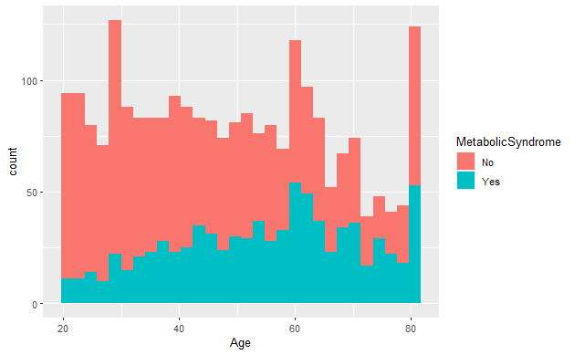

```r
ggplot(data = data, aes(x = Age, fill = MetabolicSyndrome)) + geom_histogram()
```

Sa grafika možemo videti da stariji ljudi imaju veće šanse da obole od metaboličkog sindroma. Ova promenjiva može veoma uticati na naš model i nju ćemo uzeti u obzir.

#### Zavisnost promenjive Income i MetabolicSyndrome

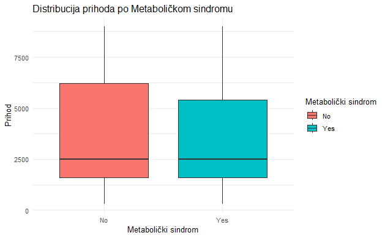

```r
ggplot(data = data, aes(x = MetabolicSyndrome, y = Income, fill = MetabolicSyndrome)) +
  geom_boxplot() +
  labs(
    title = "Distribucija prihoda po Metaboličkom sindromu",
    x = "Metabolički sindrom",
    y = "Prihod",
    fill = "Metabolički sindrom"
  ) +
  theme_minimal()
```

Sa grafika možemo videti da medijalna vrednost prihoda kod ljudi koji imaju metabolički sindrom i onih koji nemaju ista.

#### Zavisnost promenjive WaistCirc i MetabolicSyndrome

Veći obim struka često je povezan sa većim rizikom od metaboličkog sindroma. Centralna gojaznost, koja se meri obimom struka, često je indikator povećanog visceralnog (trbušnog) masnog tkiva, što može povećati rizik od metaboličkog sindroma.

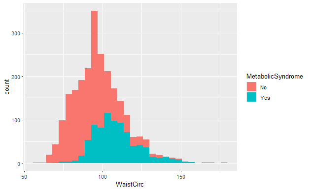

```r
ggplot(data = data, aes(x = WaistCirc, fill = MetabolicSyndrome)) + geom_histogram()
```

Sa grafika možemo primetiti da WaistCirc utiče na našu target promenjivu jer ljudi sa većim obimom struka imaju veće šanse da obole od metabolickog sindroma. Ovu promenjivu ćemo uzeti u obzir.

#### Zavisnost promenjive BMI i MetabolicSyndrome

Visok BMI je takođe faktor rizika za metabolički sindrom. Prekomerna težina, posebno u kombinaciji sa centralnom gojaznošću, može doprineti insulinskoj rezistenciji, dislipidemiji i visokom krvnom pritisku - karakterističnim faktorima metaboličkog sindroma.

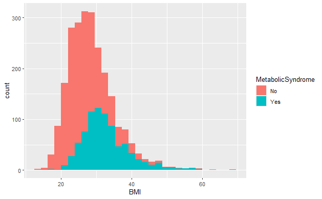

```r
ggplot(data = data, aes(x = BMI, fill = MetabolicSyndrome)) + geom_histogram()
```

Za promenljivu BMI isto vaši kao i za promenljivu WaistCirc. Ljudi sa većim BMI imaju veće šanse da obole od metaboličkog sindroma. Ova promenljiva je važna za naš model. Hajde da napravimo novu promenjivu od BMI.

```r
data$BMI_category <- ifelse(data$BMI < 18.5, "Underweight",
                            ifelse(data$BMI >= 18.5 & data$BMI <= 24.9, "Healthy Weight",
                                   ifelse(data$BMI >= 25.0 & data$BMI <= 29.9, "Overweight",
                                          "Obese")))
data$BMI_category <- factor(data$BMI_category)
```

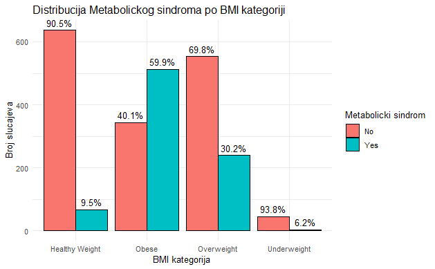

```r
data_summary_bmi <- data %>%
  group_by(BMI_category, MetabolicSyndrome) %>%
  summarise(count = n(), .groups = 'drop') %>%
  group_by(BMI_category) %>%
  mutate(percentage = count / sum(count) * 100)

ggplot(data_summary_bmi, aes(x = BMI_category, y = count, fill = MetabolicSyndrome)) +
  geom_bar(stat = "identity", position = position_dodge(width = 0.9), color = "black") +
  geom_text(aes(label = paste0(round(percentage, 1), "%")),
            position = position_dodge(width = 0.9), vjust = -0.5) +
  labs(
    title = "Distribucija Metabolickog sindroma po BMI kategoriji",
    x = "BMI kategorija",
    y = "Broj slucajeva",
    fill = "Metabolicki sindrom"
  ) +
  theme_minimal()
```

#### Zavisnost promenljive Albuminuria i MetabolicSyndrome

Albumini su zapravo proteina koji dospoevaju u urin kada bubrezi nisu u mogućnosti da prerade velike količine proteina unete hranom. Provera albumina u urinu se vrši jutarnjim drugim uzorkom. Povećana koncentracija albumina u urinu (albuminurija) može ukazivati na oštećenje bubrega, što je često povezano sa metaboličkim poremećajima kao što su dijabetes i hipertenzija, što su faktori rizika za metabolički sindrom.

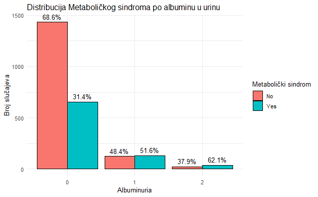

```r
data_summary_albuminuria <- data %>%
  group_by(Albuminuria, MetabolicSyndrome) %>%
  summarise(count = n(), .groups = 'drop') %>%
  group_by(Albuminuria) %>%
  mutate(percentage = count / sum(count) * 100)

ggplot(data_summary_albuminuria, aes(x = as.factor(Albuminuria), y = count, fill = MetabolicSyndrome)) +
  geom_bar(stat = "identity", position = position_dodge(width = 0.9), color = "black") +
  geom_text(aes(label = paste0(round(percentage, 1), "%")),
            position = position_dodge(width = 0.9), vjust = -0.5) +
  labs(
    title = "Distribucija Metaboličkog sindroma po albuminu u urinu",
    x = "Albuminuria",
    y = "Broj slučajeva",
    fill = "Metabolički sindrom"
  ) +
  theme_minimal()
```

Sa ovog grafika možemo videti da najviše ima ljudi koji imaju 0 albumina u urinu i oni najredje oboljevaju od ovog sindroma. Ljudi sa vrednosti 1 imaju skoro jednake šanse a ljudi koji imaju vrednost 2 imaju najveće šanse od oboljevanja. Pošto se ovde javljaju samo tri vrednosti, napravićemo novu promenjivu od ove koju ćemo faktorisati.

```r
data$Albuminuria_New = factor(data$Albuminuria)
summary(data)
```

```
      seqn            Age            Sex            Marital         Income              Race
 Min.   :62161   Min.   :20.00   Female:1211   Divorced : 242   Min.   : 300   Asian      :349
 1st Qu.:64591   1st Qu.:34.00   Male  :1190   Married  :1303   1st Qu.:1600   Black      :548
 Median :67059   Median :48.00                 Separated:  95   Median :2500   Hispanic   :257
 Mean   :67031   Mean   :48.69                 Single   : 595   Mean   :3932   MexAmerican:253
 3rd Qu.:69495   3rd Qu.:63.00                 Widowed  : 166   3rd Qu.:6200   Other      : 61
 Max.   :71915   Max.   :80.00                                  Max.   :9000   White      :933
   WaistCirc           BMI         Albuminuria        UrAlbCr           UricAcid       BloodGlucose
 Min.   : 56.20   Min.   :13.40   Min.   :0.0000   Min.   :   1.40   Min.   : 1.800   Min.   : 39.0
 1st Qu.: 87.00   1st Qu.:24.00   1st Qu.:0.0000   1st Qu.:   4.45   1st Qu.: 4.500   1st Qu.: 92.0
 Median : 97.00   Median :27.70   Median :0.0000   Median :   7.07   Median : 5.400   Median : 99.0
 Mean   : 98.26   Mean   :28.69   Mean   :0.1541   Mean   :  43.63   Mean   : 5.489   Mean   :108.2
 3rd Qu.:107.20   3rd Qu.:32.00   3rd Qu.:0.0000   3rd Qu.:  13.69   3rd Qu.: 6.400   3rd Qu.:110.0
 Max.   :176.00   Max.   :68.70   Max.   :2.0000   Max.   :5928.00   Max.   :11.300   Max.   :382.0
      HDL         Triglycerides    MetabolicSyndrome         BMI_category Albuminuria_New
 Min.   : 14.00   Min.   :  26.0   No :1579          Healthy Weight:704   0:2089
 1st Qu.: 43.00   1st Qu.:  75.0   Yes: 822          Obese         :857   1: 254
 Median : 51.00   Median : 103.0                     Overweight    :792   2:  58
 Mean   : 53.37   Mean   : 128.1                     Underweight   : 48
 3rd Qu.: 62.00   3rd Qu.: 150.0
 Max.   :156.00   Max.   :1562.0
```

#### Zavisnost promenjive UrAlbCr i MetabolicSyndrome

Ovaj odnos može biti koristan pokazatelj bubrega i rizika od kardiovaskularnih bolesti, koji su često povezani sa metaboličkim sindromom. Vrednost ove promenjive nam zavisi i od količine kreatinina u krvi koji je jedan od pokazatelja mogućih oštećenja bubrega.

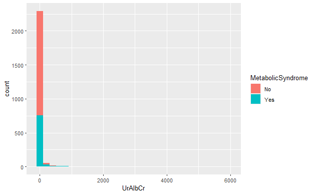

```r
ggplot(data = data, aes(x = UrAlbCr, fill = MetabolicSyndrome)) + geom_histogram()
```

Normalan odnos albumina i kreatinina u urinu je do 30mg/g. Možemo primetiti da ovde imamo i neke izuzetne vrednosti, da vidimo koliko ih imamo preko hiljadu.

```r
length(which(data$UrAlbCr>1000))
```

```
[1] 18
```

Ima ih 18. Hajde da vidimo koje su to vrednosti

```r
data$UrAlbCr[data$UrAlbCr > 1000]
```

```
 [1] 3267.57 3284.62 1777.05 2750.00 2238.10 2403.85 1817.31 1276.60 1511.11 3666.67 1024.31 2360.66
[13] 5928.00 2047.17 2403.85 4462.81 1016.67 3500.00
```

Hajde da vidimo da vidimo prosek i medijanu godina za ove ljude.

```r
mean(data$Age[data$UrAlbCr > 1000], na.rm = TRUE)
```

```
[1] 63.5
```

```r
median(data$Age[data$UrAlbCr > 1000], na.rm = TRUE)
```

```
[1] 66
```

Možemo primetiti da su to mahom stariji ljudi, koji imaju verovatno imaju bolesti bubrega i otuda ovakve vrednosti. Hajde da vidimo koliko imamo ljudi za koje se smatra da imaju povišen odnos albumina i kreatinina u krvi.

```r
length(which(data$UrAlbCr>30))
```

```
[1] 311
```

Vidimo da imamo 311 ljudi koji imaju veći odnos albumina i kreatinina u krvi. Veće referentne vrednosti ovog parametra ukazuju na bolesti bubrega. Hajde da uzmemo u obzir samo ljude koji imaju normalne vrednosti.

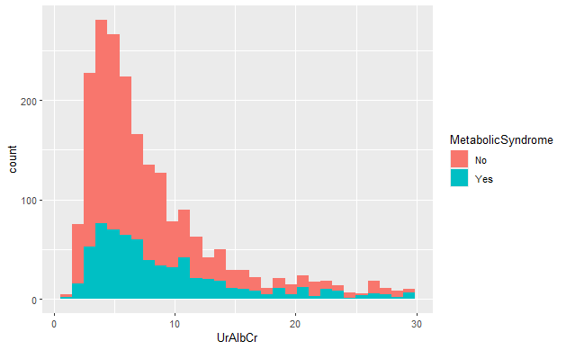

```r
ggplot(data = filter(data, data$UrAlbCr<30), aes(x = UrAlbCr, fill = MetabolicSyndrome)) + geom_histogram()
```

```r
percentage_under_10 <- sum(data$UrAlbCr < 10 & data$MetabolicSyndrome == "Yes") / sum(data$UrAlbCr < 15)
percentage_from_10_to_30 <- sum(data$UrAlbCr >= 10 & data$UrAlbCr <= 30 & data$MetabolicSyndrome == "Yes") / sum(data$UrAlbCr >= 10 & data$UrAlbCr <= 30)
percentage_above_30 <- sum(data$UrAlbCr > 30 & data$MetabolicSyndrome == "Yes") / sum(data$UrAlbCr > 30)
cat("Under 10:", percentage_under_10 * 100, "%\n")
```

```
Under 10: 23.23069 %
```

```r
cat("Between 10 and 30:", percentage_from_10_to_30 * 100, "%\n")
```

```
Between 10 and 30: 42.08566 %
```

```r
cat("Above 30:", percentage_above_30 * 100, "%\n")
```

```
Above 30: 53.37621 %
```

Možemo primetiti da se šanse povećavaju. Hajde da napravimo novu promenljivu koja će imati tri vrednosti kao što smo ovde izračunali.

```r
data$UrAlbCr_New = ifelse(data$UrAlbCr < 10, "Under 10", ifelse(data$UrAlbCr <= 30, "Between 10 and 30", "Above 30"))
data$UrAlbCr_New = factor(data$UrAlbCr_New)
summary(data)
```

```
      seqn            Age            Sex            Marital         Income              Race
 Min.   :62161   Min.   :20.00   Female:1211   Divorced : 242   Min.   : 300   Asian      :349
 1st Qu.:64591   1st Qu.:34.00   Male  :1190   Married  :1303   1st Qu.:1600   Black      :548
 Median :67059   Median :48.00                 Separated:  95   Median :2500   Hispanic   :257
 Mean   :67031   Mean   :48.69                 Single   : 595   Mean   :3932   MexAmerican:253
 3rd Qu.:69495   3rd Qu.:63.00                 Widowed  : 166   3rd Qu.:6200   Other      : 61
 Max.   :71915   Max.   :80.00                                  Max.   :9000   White      :933
   WaistCirc           BMI         Albuminuria        UrAlbCr           UricAcid       BloodGlucose
 Min.   : 56.20   Min.   :13.40   Min.   :0.0000   Min.   :   1.40   Min.   : 1.800   Min.   : 39.0
 1st Qu.: 87.00   1st Qu.:24.00   1st Qu.:0.0000   1st Qu.:   4.45   1st Qu.: 4.500   1st Qu.: 92.0
 Median : 97.00   Median :27.70   Median :0.0000   Median :   7.07   Median : 5.400   Median : 99.0
 Mean   : 98.26   Mean   :28.69   Mean   :0.1541   Mean   :  43.63   Mean   : 5.489   Mean   :108.2
 3rd Qu.:107.20   3rd Qu.:32.00   3rd Qu.:0.0000   3rd Qu.:  13.69   3rd Qu.: 6.400   3rd Qu.:110.0
 Max.   :176.00   Max.   :68.70   Max.   :2.0000   Max.   :5928.00   Max.   :11.300   Max.   :382.0
      HDL         Triglycerides    MetabolicSyndrome         BMI_category Albuminuria_New
 Min.   : 14.00   Min.   :  26.0   No :1579          Healthy Weight:704   0:2089
 1st Qu.: 43.00   1st Qu.:  75.0   Yes: 822          Obese         :857   1: 254
 Median : 51.00   Median : 103.0                     Overweight    :792   2:  58
 Mean   : 53.37   Mean   : 128.1                     Underweight   : 48
 3rd Qu.: 62.00   3rd Qu.: 150.0
 Max.   :156.00   Max.   :1562.0
            UrAlbCr_New
 Above 30         : 311
 Between 10 and 30: 537
 Under 10         :1553
```

#### Zavisnost promenljive UricAcid i MetabolicSyndrome

Povišen nivo mokraćne kiseline može biti povezan sa metaboličkim sindromom, posebno sa insulinskom rezistencijom i hipertenzijom.

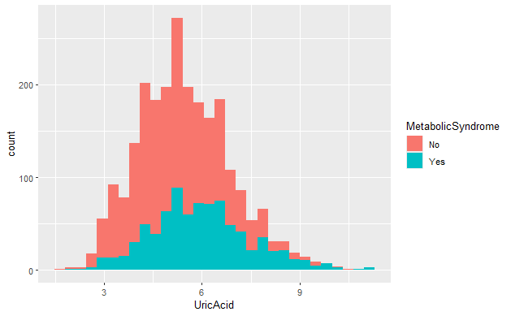

```r
ggplot(data = data, aes(x = UricAcid, fill = MetabolicSyndrome)) + geom_histogram()
```

Sa ovog grafika takodje možemo da vidimo da mokraćna kiselina blago utiče na sindrom kao i odnos albumina i kreatitina u urinu. Ova promenljiva će biti pod znakom pitanja i videćemo šta ćemo uraditi sa njom.

#### Zavisnost promenljive BloodGlucose i MetabolicSyndrome

Visok nivo glukoze u krvi (hiperglikemija) česta je karakteristika dijabetesa tipa 2, koji je jedan od ključnih komponenti metaboličkog sindroma. Povišen nivo šećera u krvi može se odraziti na ishranu koja mora biti prilagodjena ljudima koji imaju povišen šećer. Visok nivo šećera takodje negativno utiče na bubreg koji u dužem vremenskom periodu može da dovede do hronične bolesti istih.

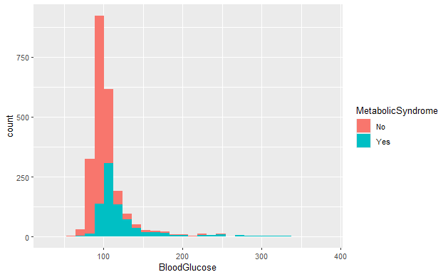

```r
ggplot(data = data, aes(x = BloodGlucose, fill = MetabolicSyndrome)) + geom_histogram()
```

Šećer u krvi nam je važna promenljiva i to možemo videti sa prethodnog grafika. Viši nivo šećera povećava šanse od metaboličkog sindroma. Možemo primetiti da i šećer u krvi ima neke izuzetne vrednosti. Hajde da vidimo koliko ljudi ima šećer u krvi preko 200.

```r
length(which(data$BloodGlucose>200))
```

```
[1] 79
```

Hajde da proverimo prosek i medijanu godina za ove ljude.

```r
mean(data$Age[data$BloodGlucose > 200], na.rm = TRUE)
```

```
[1] 56.56962
```

```r
median(data$Age[data$BloodGlucose > 200], na.rm = TRUE)
```

```
[1] 58
```

Vidimo da su to sredovečni ljudi koji verovatno boluju od dijabetesa. Hajde da proverimo još neke parametre.

```r
mean(data$UrAlbCr[data$BloodGlucose > 200], na.rm = TRUE)
```

```
[1] 149.4756
```

```r
median(data$UrAlbCr[data$BloodGlucose > 200], na.rm = TRUE)
```

```
[1] 21.4
```

```r
summary(data$UrAlbCr)
```

```
   Min. 1st Qu.  Median    Mean 3rd Qu.    Max.
   1.40    4.45    7.07   43.63   13.69 5928.00
```

A možemo primetiti da su to i ljudi koji imaju povišen odnos albumina i kreatinina u urinu. Ovo takodje ukazuje na probleme sa bubrezima. Poznato je da povisen šećer u krvi oštećuje bubrege i stvara hroničnu bolest bubrega. Normalan šećer se kreće ispod 100. Predijabetes je u rasponu od 100 do 125, a dijabetes se smatra za vrednosti veće od 126. Hajde da napravimo novu promenjivu, Diabetes.

```r
data$Diabetes <- ifelse(data$BloodGlucose < 100, "No",
                        ifelse(data$BloodGlucose < 126, "Prediabetes", "Yes"))
data$Diabetes <- factor(data$Diabetes)
summary(data)
```

```
      seqn            Age            Sex            Marital         Income              Race
 Min.   :62161   Min.   :20.00   Female:1211   Divorced : 242   Min.   : 300   Asian      :349
 1st Qu.:64591   1st Qu.:34.00   Male  :1190   Married  :1303   1st Qu.:1600   Black      :548
 Median :67059   Median :48.00                 Separated:  95   Median :2500   Hispanic   :257
 Mean   :67031   Mean   :48.69                 Single   : 595   Mean   :3932   MexAmerican:253
 3rd Qu.:69495   3rd Qu.:63.00                 Widowed  : 166   3rd Qu.:6200   Other      : 61
 Max.   :71915   Max.   :80.00                                  Max.   :9000   White      :933
   WaistCirc           BMI         Albuminuria        UrAlbCr           UricAcid       BloodGlucose
 Min.   : 56.20   Min.   :13.40   Min.   :0.0000   Min.   :   1.40   Min.   : 1.800   Min.   : 39.0
 1st Qu.: 87.00   1st Qu.:24.00   1st Qu.:0.0000   1st Qu.:   4.45   1st Qu.: 4.500   1st Qu.: 92.0
 Median : 97.00   Median :27.70   Median :0.0000   Median :   7.07   Median : 5.400   Median : 99.0
 Mean   : 98.26   Mean   :28.69   Mean   :0.1541   Mean   :  43.63   Mean   : 5.489   Mean   :108.2
 3rd Qu.:107.20   3rd Qu.:32.00   3rd Qu.:0.0000   3rd Qu.:  13.69   3rd Qu.: 6.400   3rd Qu.:110.0
 Max.   :176.00   Max.   :68.70   Max.   :2.0000   Max.   :5928.00   Max.   :11.300   Max.   :382.0
      HDL         Triglycerides    MetabolicSyndrome         BMI_category Albuminuria_New
 Min.   : 14.00   Min.   :  26.0   No :1579          Healthy Weight:704   0:2089
 1st Qu.: 43.00   1st Qu.:  75.0   Yes: 822          Obese         :857   1: 254
 Median : 51.00   Median : 103.0                     Overweight    :792   2:  58
 Mean   : 53.37   Mean   : 128.1                     Underweight   : 48
 3rd Qu.: 62.00   3rd Qu.: 150.0
 Max.   :156.00   Max.   :1562.0
            UrAlbCr_New          Diabetes
 Above 30         : 311   No         :1204
 Between 10 and 30: 537   Prediabetes: 893
 Under 10         :1553   Yes        : 304
```

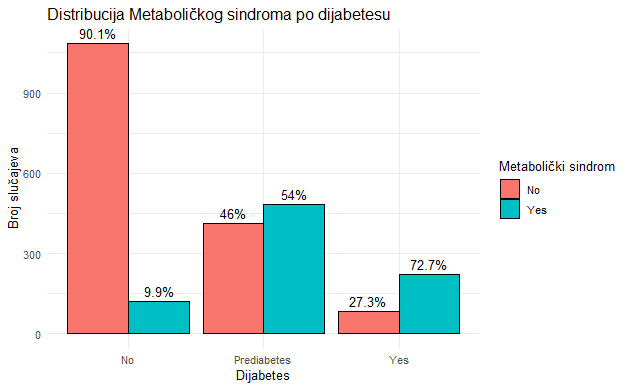

```r
data_summary_diabetes <- data %>%
  group_by(Diabetes, MetabolicSyndrome) %>%
  summarise(count = n(), .groups = 'drop') %>%
  group_by(Diabetes) %>%
  mutate(percentage = count / sum(count) * 100)
ggplot(data_summary_diabetes, aes(x = Diabetes, y = count, fill = MetabolicSyndrome)) +
  geom_bar(stat = "identity", position = position_dodge(width = 0.9), color = "black") +
  geom_text(aes(label = paste0(round(percentage, 1), "%")),
            position = position_dodge(width = 0.9), vjust = -0.5) +
  labs(
    title = "Distribucija Metaboličkog sindroma po dijabetesu",
    x = "Dijabetes",
    y = "Broj slučajeva",
    fill = "Metabolički sindrom"
  ) +
  theme_minimal()
```

#### Zavisnost promenljive HDL i MetabolicSyndrome

Nizak nivo HDL holesterola (tzv. “dobrog” holesterola) povezan je sa povećanim rizikom od metaboličkog sindroma, jer HDL ima zaštitnu ulogu protiv ateroskleroze. Ljudi sa povećanim količinama HDL su ljudi koji unsoe dovoljne količine zdravih masti (omega-3-masne kiseline).

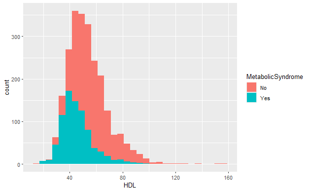

```r
ggplot(data = data, aes(x = HDL, fill = MetabolicSyndrome)) + geom_histogram()
```

Možemo primetiti da i ovde postoje izuzetne vrednosti. Hajde da vidimo koliko ima ljudi sa HDL-om preko 100.

```r
length(which(data$HDL > 100))
```

```
[1] 16
```

Ima ih 16. S obzirom da je HDL dobar holesterol, hajde da vidimo kako se kreću vrednosti za šećer kod ovih ljudi.

```r
mean(data$BloodGlucose[data$HDL > 100], na.rm = TRUE)
```

```
[1] 95
```

```r
median(data$BloodGlucose[data$HDL > 100], na.rm = TRUE)
```

```
[1] 92.5
```

```r
summary(data$BloodGlucose)
```

```
   Min. 1st Qu.  Median    Mean 3rd Qu.    Max.
   39.0    92.0    99.0   108.2   110.0   382.0
```

Vidimo da su ispod medijane i proseka, što znači da verovatno nemaju problema sa šećerom što je logično s obzirom na vrednost HDL. Hajde da proverimo i trigliceride.

```r
mean(data$Triglycerides[data$HDL > 100], na.rm = TRUE)
```

```
[1] 81.9375
```

```r
median(data$Triglycerides[data$HDL > 100], na.rm = TRUE)
```

```
[1] 69
```

```r
summary(data$Triglycerides)
```

```
   Min. 1st Qu.  Median    Mean 3rd Qu.    Max.
   26.0    75.0   103.0   128.1   150.0  1562.0
```

Kao što smo i pretpostavili, imaju ih poprilično manje u odnosu na sve ljude, tako da je ovo logično odstupanje. HDL(dobar holesterol) nam je važna promenljiva i možemo videti sa grafika da ljudi sa nižim nivoom dobrog holesterola imaju veće šanse da obole od metaboličkog sindroma. Ovu promenljivu ćemo uključiti u naš model. Probaćemo da ovu promenjivu podelimo na tri dela i da vidimo koliko ljudi procentualno oboljeva od ovog sindroma. Na osnovu ovog grafika uzećemo ljude od 0 do 50, od 50 do 100 i više od 100.

```r
percentage_under_50 <- sum(data$HDL < 50 & data$MetabolicSyndrome == "Yes") / sum(data$HDL < 50)
percentage_from_50_to_100 <- sum(data$HDL >= 50 & data$HDL <= 100 & data$MetabolicSyndrome == "Yes") / sum(data$HDL >= 50 & data$HDL <= 100)
percentage_above_100 <- sum(data$HDL > 100 & data$MetabolicSyndrome == "Yes") / sum(data$HDL > 100)
cat("Under 50:", percentage_under_50 * 100, "%\n")
```

```
Under 50: 53.09326 %
```

```r
cat("Between 50 and 100:", percentage_from_50_to_100 * 100, "%\n")
```

```
Between 50 and 100: 18.97081 %
```

```r
cat("Above 100:", percentage_above_100 * 100, "%\n")
```

```
Above 100: 0 %
```

Kao što možemo videti, ljudi sa HDL ispod 50 imaju malo više od 50% šanse da obole, dok ljudi izmedju 50 i 100 imaju skoro 20%. Ljudi sa HDL preko 100 ne oboljevaju od ovog sindroma. Kao i kod odnosa albumina i kreatinina, napravićemo novu promenljivu.

```r
data$HDL_New = ifelse(data$HDL < 50, "Under 50", ifelse(data$HDL <= 100, "Between 50 and 100", "Above 100"))
data$HDL_New = factor(data$HDL_New)
summary(data)
```

```
      seqn            Age            Sex            Marital         Income              Race
 Min.   :62161   Min.   :20.00   Female:1211   Divorced : 242   Min.   : 300   Asian      :349
 1st Qu.:64591   1st Qu.:34.00   Male  :1190   Married  :1303   1st Qu.:1600   Black      :548
 Median :67059   Median :48.00                 Separated:  95   Median :2500   Hispanic   :257
 Mean   :67031   Mean   :48.69                 Single   : 595   Mean   :3932   MexAmerican:253
 3rd Qu.:69495   3rd Qu.:63.00                 Widowed  : 166   3rd Qu.:6200   Other      : 61
 Max.   :71915   Max.   :80.00                                  Max.   :9000   White      :933
   WaistCirc           BMI         Albuminuria        UrAlbCr           UricAcid       BloodGlucose
 Min.   : 56.20   Min.   :13.40   Min.   :0.0000   Min.   :   1.40   Min.   : 1.800   Min.   : 39.0
 1st Qu.: 87.00   1st Qu.:24.00   1st Qu.:0.0000   1st Qu.:   4.45   1st Qu.: 4.500   1st Qu.: 92.0
 Median : 97.00   Median :27.70   Median :0.0000   Median :   7.07   Median : 5.400   Median : 99.0
 Mean   : 98.26   Mean   :28.69   Mean   :0.1541   Mean   :  43.63   Mean   : 5.489   Mean   :108.2
 3rd Qu.:107.20   3rd Qu.:32.00   3rd Qu.:0.0000   3rd Qu.:  13.69   3rd Qu.: 6.400   3rd Qu.:110.0
 Max.   :176.00   Max.   :68.70   Max.   :2.0000   Max.   :5928.00   Max.   :11.300   Max.   :382.0
      HDL         Triglycerides    MetabolicSyndrome         BMI_category Albuminuria_New
 Min.   : 14.00   Min.   :  26.0   No :1579          Healthy Weight:704   0:2089
 1st Qu.: 43.00   1st Qu.:  75.0   Yes: 822          Obese         :857   1: 254
 Median : 51.00   Median : 103.0                     Overweight    :792   2:  58
 Mean   : 53.37   Mean   : 128.1                     Underweight   : 48
 3rd Qu.: 62.00   3rd Qu.: 150.0
 Max.   :156.00   Max.   :1562.0
            UrAlbCr_New          Diabetes                  HDL_New
 Above 30         : 311   No         :1204   Above 100         :  16
 Between 10 and 30: 537   Prediabetes: 893   Between 50 and 100:1302
 Under 10         :1553   Yes        : 304   Under 50          :1083
```

#### Zavisnost promenljive Triglycerides i MetabolicSyndrome

Visok nivo triglicerida u krvi čest je kod metaboličkog sindroma i može biti indikator insulinske rezistencije i metaboličkih poremećaja. Ljudi sa povišen trigliceridima su ljudi koji jedu masniju hranu, sa više nezdravih masti koje zapušavaju krvne sudove.

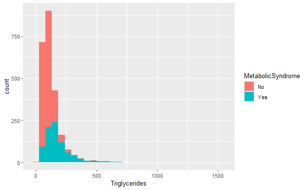

```r
ggplot(data = data, aes(x = Triglycerides, fill = MetabolicSyndrome)) + geom_histogram()
```

Sa grafika možemo primetiti da imamo izuzetne vrednosti i kod triglecirida. Hajde da vidimo kolimo ljudi imamo sa trigleciridima preko 500.

```r
length(which(data$Triglycerides>500))
```

```
[1] 26
```

```r
data$Triglycerides[data$Triglycerides>500]
```

```
 [1]  565  589  668  624  626  681  584  979 1311  560  510  564  553  528  539  610  535  688  559  666
[21]  526  700 1562  511  814  607
```

Imamo ih 26. Hajde da proverimo neku povezanost sa ostalim promenjivima. Možemo prvo proveriti sa BMI jer bi logično mogla da postoji neka povezanost.

```r
mean(data$BMI[data$Triglycerides > 500], na.rm = TRUE)
```

```
[1] 30.75385
```

```r
median(data$BMI[data$Triglycerides > 500], na.rm = TRUE)
```

```
[1] 28.9
```

```r
summary(data$BMI)
```

```
   Min. 1st Qu.  Median    Mean 3rd Qu.    Max.
  13.40   24.00   27.70   28.69   32.00   68.70
```

Vidimo su to ljudi malo iznad proseka i medija po BMI. Hajde da proverimo kakve vrednosti HDL imaju ove osobe

```r
mean(data$HDL[data$Triglycerides > 500], na.rm = TRUE)
```

```
[1] 34.11538
```

```r
median(data$HDL[data$Triglycerides > 500], na.rm = TRUE)
```

```
[1] 31.5
```

```r
summary(data$HDL)
```

```
   Min. 1st Qu.  Median    Mean 3rd Qu.    Max.
  14.00   43.00   51.00   53.37   62.00  156.00
```

To su osobe sa HDL-om ispod proseka i medijane, što smo i očekivali. Ovo odstupanje je takodje logično. Sa datog grafika vidimo da nam je i promenljiva Triglycerides izuzetno važna i da ljudi sa višim nivoom triglicerida imaju veće šanse da obole od metaboličkog sindroma. Hajde da vidimo da li postoji neka medjusobna zavisnost izmedju featura i da li to možemo da uključimo u naš model. Hajde da vidimo koliko procenta ljudi ima metabolički sindrom sa trigleciridima ispod 125, koliko sa trigliceridima izmedju 125 i 500 a koliko sa preko 500.

```r
percentage_under_125 <- sum(data$Triglycerides < 125 & data$MetabolicSyndrome == "Yes") / sum(data$Triglycerides < 125)
percentage_from_125_to_500 <- sum(data$Triglycerides >= 125 & data$Triglycerides <= 500 & data$MetabolicSyndrome == "Yes") / sum(data$Triglycerides >= 125 & data$Triglycerides <= 500)
percentage_above_500 <- sum(data$Triglycerides >= 500 & data$MetabolicSyndrome == "Yes") / sum(data$Triglycerides >= 500)
cat("Under 125:", percentage_under_125 * 100, "%\n")
```

```
Under 125: 17.84777 %
```

```r
cat("Between 125 and 500:", percentage_from_125_to_500 * 100, "%\n")
```

```
Between 125 and 500: 61.69213 %
```

```r
cat("Above 500:", percentage_above_500 * 100, "%\n")
```

```
Above 500: 96.15385 %
```

```r
data$Triglycerides_New = ifelse(data$Triglycerides < 125, "Under 125", ifelse(data$Triglycerides <= 125, "Between 125 and 500", "Above 500"))
data$Triglycerides_New = factor(data$Triglycerides_New)
summary(data)
```

```
      seqn            Age            Sex            Marital         Income              Race
 Min.   :62161   Min.   :20.00   Female:1211   Divorced : 242   Min.   : 300   Asian      :349
 1st Qu.:64591   1st Qu.:34.00   Male  :1190   Married  :1303   1st Qu.:1600   Black      :548
 Median :67059   Median :48.00                 Separated:  95   Median :2500   Hispanic   :257
 Mean   :67031   Mean   :48.69                 Single   : 595   Mean   :3932   MexAmerican:253
 3rd Qu.:69495   3rd Qu.:63.00                 Widowed  : 166   3rd Qu.:6200   Other      : 61
 Max.   :71915   Max.   :80.00                                  Max.   :9000   White      :933
   WaistCirc           BMI         Albuminuria        UrAlbCr           UricAcid       BloodGlucose
 Min.   : 56.20   Min.   :13.40   Min.   :0.0000   Min.   :   1.40   Min.   : 1.800   Min.   : 39.0
 1st Qu.: 87.00   1st Qu.:24.00   1st Qu.:0.0000   1st Qu.:   4.45   1st Qu.: 4.500   1st Qu.: 92.0
 Median : 97.00   Median :27.70   Median :0.0000   Median :   7.07   Median : 5.400   Median : 99.0
 Mean   : 98.26   Mean   :28.69   Mean   :0.1541   Mean   :  43.63   Mean   : 5.489   Mean   :108.2
 3rd Qu.:107.20   3rd Qu.:32.00   3rd Qu.:0.0000   3rd Qu.:  13.69   3rd Qu.: 6.400   3rd Qu.:110.0
 Max.   :176.00   Max.   :68.70   Max.   :2.0000   Max.   :5928.00   Max.   :11.300   Max.   :382.0
      HDL         Triglycerides    MetabolicSyndrome         BMI_category Albuminuria_New
 Min.   : 14.00   Min.   :  26.0   No :1579          Healthy Weight:704   0:2089
 1st Qu.: 43.00   1st Qu.:  75.0   Yes: 822          Obese         :857   1: 254
 Median : 51.00   Median : 103.0                     Overweight    :792   2:  58
 Mean   : 53.37   Mean   : 128.1                     Underweight   : 48
 3rd Qu.: 62.00   3rd Qu.: 150.0
 Max.   :156.00   Max.   :1562.0
            UrAlbCr_New          Diabetes                  HDL_New               Triglycerides_New
 Above 30         : 311   No         :1204   Above 100         :  16   Above 500          : 859
 Between 10 and 30: 537   Prediabetes: 893   Between 50 and 100:1302   Between 125 and 500:  18
 Under 10         :1553   Yes        : 304   Under 50          :1083   Under 125          :1524
```

## Zavisnost medjusobnih feature-a

#### Zavisnost BMI i WaistCirc

Pre svega ćemo proveriti da li postoji zavisnost izmedju BMI i WaistCirc. Iz domenskog znanja znamo da to može biti blisko povezano

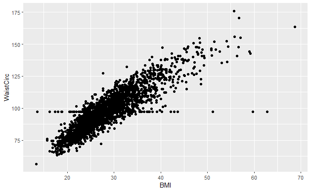

```r
ggplot(data = data, aes(x = BMI, y = WaistCirc)) + geom_point()
```

Vidimo da postoji korelacija izmedju BMI i WaistCirc. Hajde da u ovaj grafik dodamo i MetabolicSyndrome.

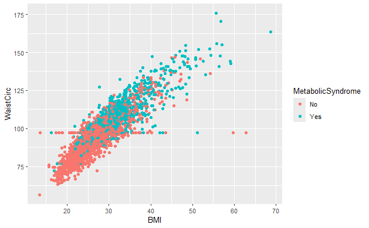

```r
ggplot(data = data, aes(x = BMI, y = WaistCirc, color = MetabolicSyndrome)) + geom_point()
```

Sa grafika možemo videti da su BMI i WaistCirc kolinearni. S ozbzirom da su obe promenjive važne za naš model, mi ćemo od ove dve promenjive napraviti jednu koja predstavlja BMI_WaistCirc_ratio i napravićemo tako što cćemo podeliti BMI sa WaistCirc.

```r
data$BMI_WaistCirc_ratio <- data$BMI / data$WaistCirc
summary(data)
```

```
      seqn            Age            Sex            Marital         Income              Race
 Min.   :62161   Min.   :20.00   Female:1211   Divorced : 242   Min.   : 300   Asian      :349
 1st Qu.:64591   1st Qu.:34.00   Male  :1190   Married  :1303   1st Qu.:1600   Black      :548
 Median :67059   Median :48.00                 Separated:  95   Median :2500   Hispanic   :257
 Mean   :67031   Mean   :48.69                 Single   : 595   Mean   :3932   MexAmerican:253
 3rd Qu.:69495   3rd Qu.:63.00                 Widowed  : 166   3rd Qu.:6200   Other      : 61
 Max.   :71915   Max.   :80.00                                  Max.   :9000   White      :933
   WaistCirc           BMI         Albuminuria        UrAlbCr           UricAcid       BloodGlucose
 Min.   : 56.20   Min.   :13.40   Min.   :0.0000   Min.   :   1.40   Min.   : 1.800   Min.   : 39.0
 1st Qu.: 87.00   1st Qu.:24.00   1st Qu.:0.0000   1st Qu.:   4.45   1st Qu.: 4.500   1st Qu.: 92.0
 Median : 97.00   Median :27.70   Median :0.0000   Median :   7.07   Median : 5.400   Median : 99.0
 Mean   : 98.26   Mean   :28.69   Mean   :0.1541   Mean   :  43.63   Mean   : 5.489   Mean   :108.2
 3rd Qu.:107.20   3rd Qu.:32.00   3rd Qu.:0.0000   3rd Qu.:  13.69   3rd Qu.: 6.400   3rd Qu.:110.0
 Max.   :176.00   Max.   :68.70   Max.   :2.0000   Max.   :5928.00   Max.   :11.300   Max.   :382.0
      HDL         Triglycerides    MetabolicSyndrome         BMI_category Albuminuria_New
 Min.   : 14.00   Min.   :  26.0   No :1579          Healthy Weight:704   0:2089
 1st Qu.: 43.00   1st Qu.:  75.0   Yes: 822          Obese         :857   1: 254
 Median : 51.00   Median : 103.0                     Overweight    :792   2:  58
 Mean   : 53.37   Mean   : 128.1                     Underweight   : 48
 3rd Qu.: 62.00   3rd Qu.: 150.0
 Max.   :156.00   Max.   :1562.0
            UrAlbCr_New          Diabetes                  HDL_New               Triglycerides_New
 Above 30         : 311   No         :1204   Above 100         :  16   Above 500          : 859
 Between 10 and 30: 537   Prediabetes: 893   Between 50 and 100:1302   Between 125 and 500:  18
 Under 10         :1553   Yes        : 304   Under 50          :1083   Under 125          :1524



 BMI_WaistCirc_ratio
 Min.   :0.1402
 1st Qu.:0.2701
 Median :0.2867
 Mean   :0.2903
 3rd Qu.:0.3063
 Max.   :0.6474
```

#### Zavisnost parametara u urinu

Iz matrice korelacije na početku, možemo ustanoviti da su Albuminuria i UrAlbCr visoko korelisani, tako da ćemo izbeći korišćenje ove dve promenjive zajedno u modelima.

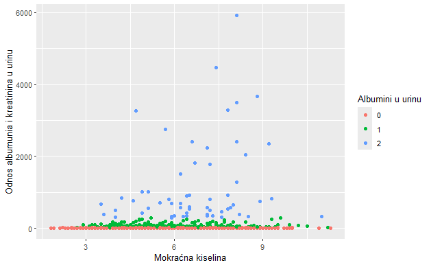

```r
ggplot(data = data, aes(x = UricAcid, y = UrAlbCr, color = Albuminuria_New)) + geom_point() +  labs(
    x = "Mokraćna kiselina",
    y = "Odnos albumunia i kreatinina u urinu",
    color = "Albumini u urinu"
  )
```

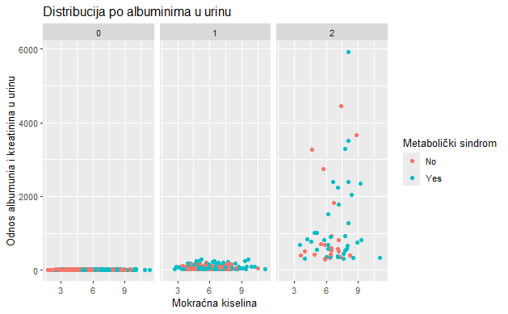

```r
ggplot(data = data, aes(x = UricAcid, y = UrAlbCr, color = MetabolicSyndrome)) + geom_point() +  labs(
    title = "Distribucija po albuminima u urinu",
    x = "Mokraćna kiselina",
    y = "Odnos albumunia i kreatinina u urinu",
    color = "Metabolički sindrom"
  ) + facet_wrap(data$Albuminuria_New)
```

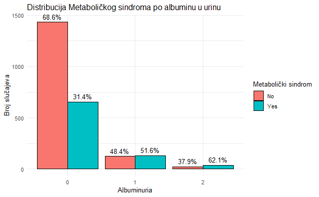

```r
ggplot(data_summary_albuminuria, aes(x = as.factor(Albuminuria), y = count, fill = MetabolicSyndrome)) +
  geom_bar(stat = "identity", position = position_dodge(width = 0.9), color = "black") +
  geom_text(aes(label = paste0(round(percentage, 1), "%")),
            position = position_dodge(width = 0.9), vjust = -0.5) +
  labs(
    title = "Distribucija Metaboličkog sindroma po albuminu u urinu",
    x = "Albuminuria",
    y = "Broj slučajeva",
    fill = "Metabolički sindrom"
  ) +
  theme_minimal()
```

#### Zavisnost izmedju HDL, Triglycerides i Diabetes

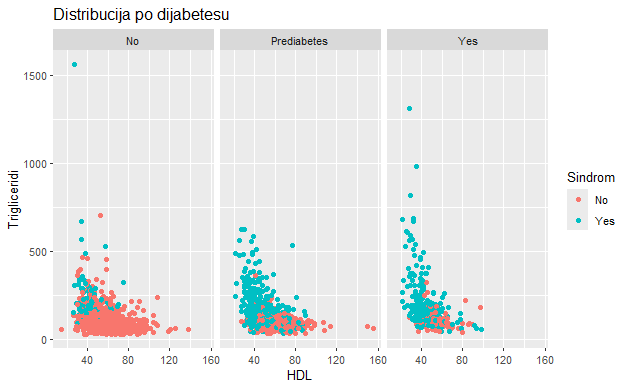

```r
ggplot(data = data, aes(x = HDL, y = Triglycerides, color = MetabolicSyndrome)) + geom_point() +  labs(
  title = "Distribucija po dijabetesu",
    x = "HDL",
    y = "Trigliceridi",
    color = "Sindrom"
  ) + facet_wrap(data$Diabetes)
```

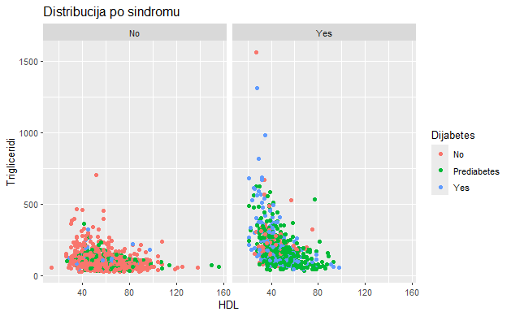

```r
ggplot(data = data, aes(x = HDL, y = Triglycerides, color = Diabetes)) + geom_point() +  labs(
  title = "Distribucija po sindromu",
    x = "HDL",
    y = "Trigliceridi",
    color = "Dijabetes"
  ) + facet_wrap(data$MetabolicSyndrome)
```

Sa ovih grafika možemo videti sa su HDL i Trigliceridi u kombinaciji moćna promenjiva, tako da ćemo njih uključiti u naš model u sinergiji.

```r
summary(data)
```

```
      seqn            Age            Sex            Marital         Income              Race
 Min.   :62161   Min.   :20.00   Female:1211   Divorced : 242   Min.   : 300   Asian      :349
 1st Qu.:64591   1st Qu.:34.00   Male  :1190   Married  :1303   1st Qu.:1600   Black      :548
 Median :67059   Median :48.00                 Separated:  95   Median :2500   Hispanic   :257
 Mean   :67031   Mean   :48.69                 Single   : 595   Mean   :3932   MexAmerican:253
 3rd Qu.:69495   3rd Qu.:63.00                 Widowed  : 166   3rd Qu.:6200   Other      : 61
 Max.   :71915   Max.   :80.00                                  Max.   :9000   White      :933
   WaistCirc           BMI         Albuminuria        UrAlbCr           UricAcid       BloodGlucose
 Min.   : 56.20   Min.   :13.40   Min.   :0.0000   Min.   :   1.40   Min.   : 1.800   Min.   : 39.0
 1st Qu.: 87.00   1st Qu.:24.00   1st Qu.:0.0000   1st Qu.:   4.45   1st Qu.: 4.500   1st Qu.: 92.0
 Median : 97.00   Median :27.70   Median :0.0000   Median :   7.07   Median : 5.400   Median : 99.0
 Mean   : 98.26   Mean   :28.69   Mean   :0.1541   Mean   :  43.63   Mean   : 5.489   Mean   :108.2
 3rd Qu.:107.20   3rd Qu.:32.00   3rd Qu.:0.0000   3rd Qu.:  13.69   3rd Qu.: 6.400   3rd Qu.:110.0
 Max.   :176.00   Max.   :68.70   Max.   :2.0000   Max.   :5928.00   Max.   :11.300   Max.   :382.0
      HDL         Triglycerides    MetabolicSyndrome         BMI_category Albuminuria_New
 Min.   : 14.00   Min.   :  26.0   No :1579          Healthy Weight:704   0:2089
 1st Qu.: 43.00   1st Qu.:  75.0   Yes: 822          Obese         :857   1: 254
 Median : 51.00   Median : 103.0                     Overweight    :792   2:  58
 Mean   : 53.37   Mean   : 128.1                     Underweight   : 48
 3rd Qu.: 62.00   3rd Qu.: 150.0
 Max.   :156.00   Max.   :1562.0
            UrAlbCr_New          Diabetes                  HDL_New               Triglycerides_New
 Above 30         : 311   No         :1204   Above 100         :  16   Above 500          : 859
 Between 10 and 30: 537   Prediabetes: 893   Between 50 and 100:1302   Between 125 and 500:  18
 Under 10         :1553   Yes        : 304   Under 50          :1083   Under 125          :1524



 BMI_WaistCirc_ratio
 Min.   :0.1402
 1st Qu.:0.2701
 Median :0.2867
 Mean   :0.2903
 3rd Qu.:0.3063
 Max.   :0.6474
```